```r
fraud_url_data <- "https://www.iii.org/table-archive/21319"
fraud_state_data <-fraud_url_data %>% read_html() %>% html_node("table") %>% html_table(fill = TRUE) %>% as_tibble()
fraud_state_data_2 <- fraud_state_data[,(1:8)]
fraud_state_data_2 <- fraud_state_data_2[-c(1), ]

names(fraud_state_data_2) <- fraud_state_data_2[1,]
```

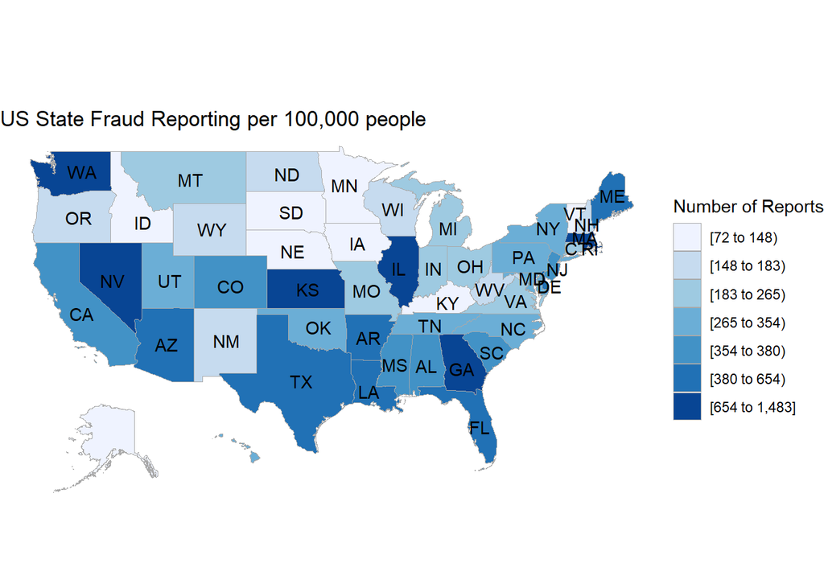

```r
fraud_state_data_2 <- fraud_state_data_2[-1,]

set1 <- fraud_state_data_2[,1:4]
set2 <- fraud_state_data_2[,5:8]

fraud_state_data_2 <- merge(set1, set2, all = TRUE)

fraud_state_chropleth_data <- fraud_state_data_2[,1:2]
data(state.regions)

colnames(fraud_state_chropleth_data) <- c("region", "value")
fraud_state_chropleth_data$region = tolower(fraud_state_chropleth_data$region)
fraud_state_chropleth_data$value <- as.numeric(gsub(",","",fraud_state_chropleth_data$value))

fraud_state_chropleth_data <- fraud_state_chropleth_data %>%
  mutate(region = replace(region, region == 'd.c.', 'district of columbia'))

fraud_state_chropleth_data <- fraud_state_chropleth_data[-c(40), ]

fraud_state_chropleth_plot <- state_choropleth(fraud_state_chropleth_data,
                 title  = "US State Fraud Reporting per 100,000 people",
                 legend = "Number of Reports")
fraud_state_chropleth_plot
```

## All of the above lines are built in order to clean and prepare data in order to build the second set choropleth similiar to bank complaints. This set is controlled to show reporting per 100000 people in order to control for population density. The first set is different for this reason, but we can see different patterns. Places such as Nevada, Georgia, Washington, and Florida have high levels of fraud relative to population. The reason in my opinion is that these areas have a high number of elderly people and thus are vulnerable to fraud incidents.

## Beyond the data and visuals built in R, looking forward we can examine why complaints or fraud occur or later in the process we can find positive solutions to such issues as complaints or fraud. There were few surprises as information unfolded. I am proud to use these tools to solve real world issues and R is important as a tool to process high volumes of data when handmade calculations are impossible or tools such as Excel are not enough to generate conclusions for this volume.